# Performance of computers

Lovdip Singh

## Goal of study

To produce and evaluate a predictive model for the performance of computers. https://archive.ics.uci.edu/ml/datasets/Computer+Hardware. The data consists of characteristics of computers (available at the time of the study) and a measure of the computer’s performance.

## Read in data

```r
machine.df <- read.csv('machine.csv')
machine.df <- as.data.frame(apply(machine.df, 2, as.numeric))
str(machine.df)
```

```
## 'data.frame':    209 obs. of  7 variables:
##  $ MYCT : num  125 29 29 29 29 26 23 23 23 23 ...
##  $ MMIN : num  256 8000 8000 8000 8000 8000 16000 16000 16000 32000 ...
##  $ MMAX : num  6000 32000 32000 32000 16000 32000 32000 32000 64000 64000 ...
##  $ CACH : num  256 32 32 32 32 64 64 64 64 128 ...
##  $ CHMIN: num  16 8 8 8 8 8 16 16 16 32 ...
##  $ CHMAX: num  128 32 32 32 16 32 32 32 32 64 ...
##  $ PRP  : num  198 269 220 172 132 ...
```

Variables are numeric values.

```r
summary(machine.df)
```

```
##       MYCT             MMIN            MMAX            CACH
##  Min.   :  17.0   Min.   :   64   Min.   :   64   Min.   :  0.00
##  1st Qu.:  50.0   1st Qu.:  768   1st Qu.: 4000   1st Qu.:  0.00
##  Median : 110.0   Median : 2000   Median : 8000   Median :  8.00
##  Mean   : 203.8   Mean   : 2868   Mean   :11796   Mean   : 25.21
##  3rd Qu.: 225.0   3rd Qu.: 4000   3rd Qu.:16000   3rd Qu.: 32.00
##  Max.   :1500.0   Max.   :32000   Max.   :64000   Max.   :256.00
##      CHMIN            CHMAX             PRP
##  Min.   : 0.000   Min.   :  0.00   Min.   :   6.0
##  1st Qu.: 1.000   1st Qu.:  5.00   1st Qu.:  27.0
##  Median : 2.000   Median :  8.00   Median :  50.0
##  Mean   : 4.699   Mean   : 18.27   Mean   : 105.6
##  3rd Qu.: 6.000   3rd Qu.: 24.00   3rd Qu.: 113.0
##  Max.   :52.000   Max.   :176.00   Max.   :1150.0
```

## Variance inflation factors

```r
round(diag(solve(cor(machine.df[, 1:6]))), 2)
```

```
##  MYCT  MMIN  MMAX  CACH CHMIN CHMAX
##  1.20  2.90  3.27  1.86  1.97  1.89
```

The VIFs for the variables are all less than 5, this means that multicollinearity should not be a problem with these regressors.

## Pairwise plot

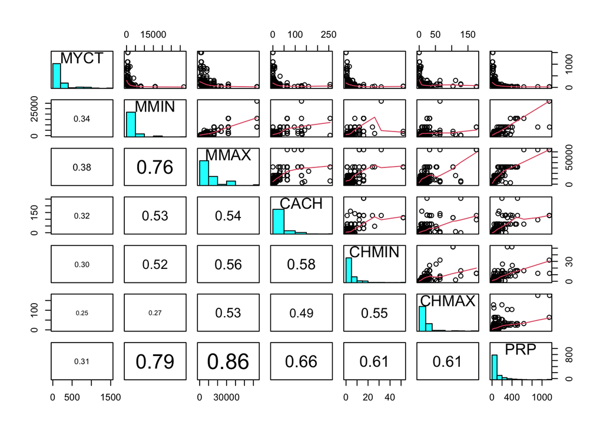

```r
pairs20x(machine.df)
```

- `PRP` is right skewed, therefore predicting the log of `PRP` makes sense.
- The relationship between most of the variables appears to be linear.
- Most of the explanatory variables do not appear to be strongly correlated with each other.
- The relationship between `MYCT` alone and the other variables appears to the weakest.
- There are some unusual data points

## Model fitting

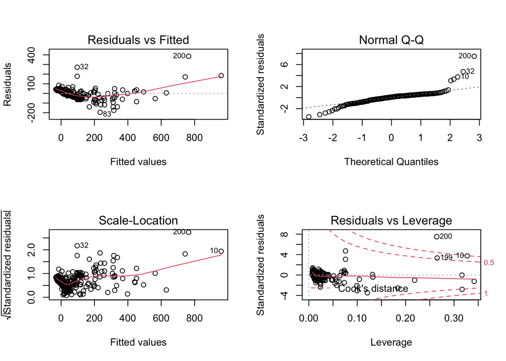

```r
fit1 <- lm(PRP~., data=machine.df)
par(mfrow=c(2,2))
plot(fit1)
```

There is some curvature in the model that needs to be addressed

## Box Cox plot

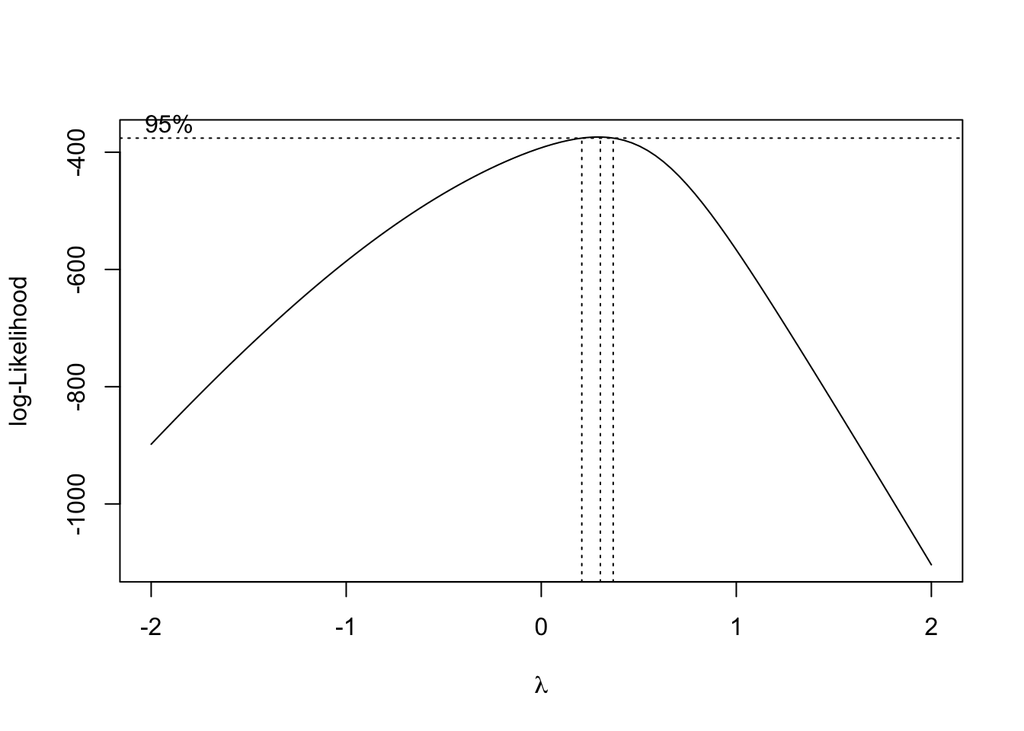

```r
library(MASS)
par(mfrow=c(1,1))
boxcox(fit1)
```

## GAM plot

```r
library(mgcv)
```

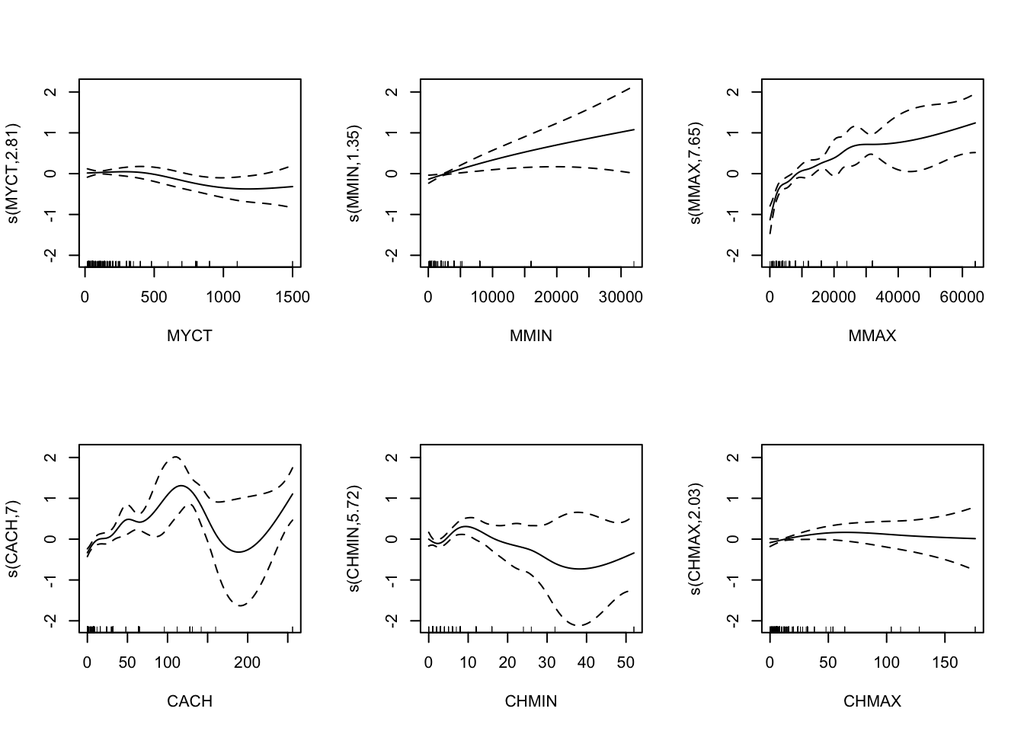

```r
gam1=gam(log(PRP)~s(MYCT)+s(MMIN)+s(MMAX)+s(CACH)+s(CHMIN)+s(CHMAX),data=machine.df)
par(mfrow=c(2,3))
plot(gam1)
```

GAM plot reveals that some variables be addressed as they show curvature. In the next iteration of the model quadratic terms will be added.

```r
fit2 <- lm(log(PRP)~.+I(MYCT^2)+I(MMIN^2)+I(MMAX^2)+I(CACH^2)+I(CHMIN^2)+I(CHMAX^2), data=machine.df)
summary(fit2)
```

```
##
## Call:
## lm(formula = log(PRP) ~ . + I(MYCT^2) + I(MMIN^2) + I(MMAX^2) +
##     I(CACH^2) + I(CHMIN^2) + I(CHMAX^2), data = machine.df)
##
## Residuals:
##      Min       1Q   Median       3Q      Max
## -1.34583 -0.24830  0.01798  0.23174  1.15601
##
## Coefficients:
##               Estimate Std. Error t value Pr(>|t|)
## (Intercept)  2.991e+00  9.951e-02  30.055  < 2e-16 ***
## MYCT        -3.904e-04  3.738e-04  -1.045 0.297495
## MMIN         6.290e-05  2.586e-05   2.433 0.015890 *
## MMAX         5.659e-05  9.236e-06   6.127 4.82e-09 ***
## CACH         1.435e-02  2.177e-03   6.593 3.91e-10 ***
## CHMIN        2.118e-02  1.411e-02   1.501 0.135001
## CHMAX        7.892e-03  3.685e-03   2.142 0.033456 *
## I(MYCT^2)   -6.728e-08  3.008e-07  -0.224 0.823209
## I(MMIN^2)   -1.480e-09  9.898e-10  -1.495 0.136454
## I(MMAX^2)   -4.648e-10  1.805e-10  -2.575 0.010767 *
## I(CACH^2)   -4.007e-05  1.024e-05  -3.911 0.000127 ***
## I(CHMIN^2)  -4.957e-04  2.798e-04  -1.771 0.078036 .
## I(CHMAX^2)  -3.211e-05  2.719e-05  -1.181 0.239074
## ---
## Signif. codes:  0 '***' 0.001 '**' 0.01 '*' 0.05 '.' 0.1 ' ' 1
##
## Residual standard error: 0.4102 on 196 degrees of freedom
## Multiple R-squared:  0.8557, Adjusted R-squared:  0.8469
## F-statistic: 96.89 on 12 and 196 DF,  p-value: < 2.2e-16
```

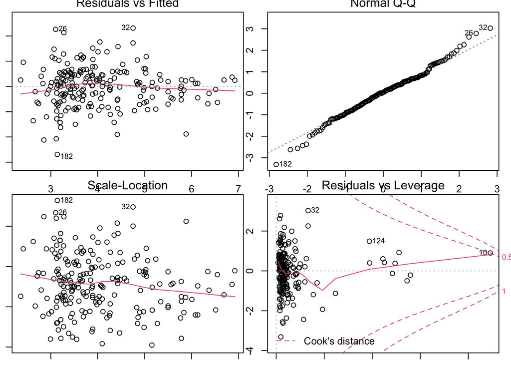

```r
par(mar=c(1,1,1,1))
par(mfrow=c(2,2))
plot(fit2)
```

Looking better, we can remove insignificant terms to make the model simpler for faster calculations for subset model calculation.

```r
fit3 <- lm(log(PRP)~.+I(MMIN^2)+I(MMAX^2)+I(CACH^2), data=machine.df)
summary(fit3)
```

```
##
## Call:
## lm(formula = log(PRP) ~ . + I(MMIN^2) + I(MMAX^2) + I(CACH^2),
##     data = machine.df)
##
## Residuals:
##      Min       1Q   Median       3Q      Max
## -1.37211 -0.22665  0.01012  0.22824  1.29075
##
## Coefficients:
##               Estimate Std. Error t value Pr(>|t|)
## (Intercept)  3.066e+00  7.686e-02  39.887  < 2e-16 ***
## MYCT        -5.278e-04  1.284e-04  -4.111 5.75e-05 ***
## MMIN         8.013e-05  2.304e-05   3.478 0.000620 ***
## MMAX         5.779e-05  8.543e-06   6.765 1.45e-10 ***
## CACH         1.445e-02  2.170e-03   6.660 2.61e-10 ***
## CHMIN        8.791e-04  6.088e-03   0.144 0.885327
## CHMAX        4.394e-03  1.686e-03   2.606 0.009854 **
## I(MMIN^2)   -1.566e-09  8.919e-10  -1.756 0.080571 .
## I(MMAX^2)   -5.525e-10  1.501e-10  -3.681 0.000299 ***
## I(CACH^2)   -4.045e-05  1.011e-05  -4.000 8.94e-05 ***
## ---
## Signif. codes:  0 '***' 0.001 '**' 0.01 '*' 0.05 '.' 0.1 ' ' 1
##
## Residual standard error: 0.4132 on 199 degrees of freedom
## Multiple R-squared:  0.8514, Adjusted R-squared:  0.8447
## F-statistic: 126.7 on 9 and 199 DF,  p-value: < 2.2e-16
```

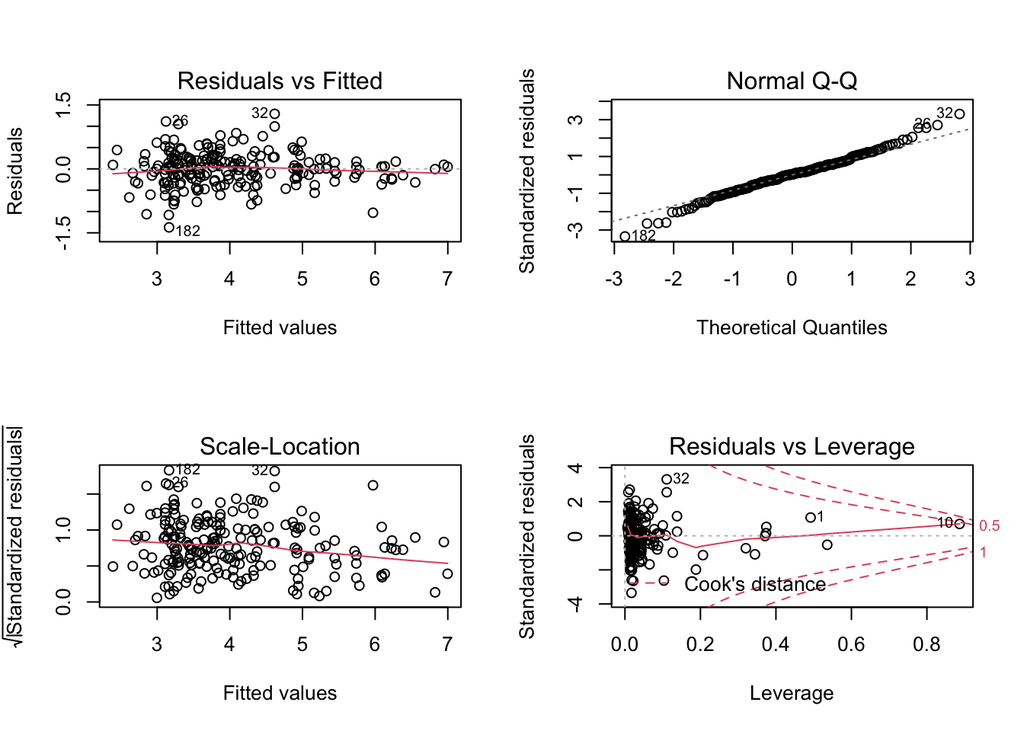

```r
par(mfrow=c(2,2))
plot(fit3)
```

## Possible subset models - top 5 models using AICc and BIC for ranking

```r
library('MuMIn')
options(na.action = "na.fail", width=120)
machine.fits <- dredge(fit3)
```

```
## Fixed term is "(Intercept)"
```

```r
machine.fits[1:5, ]
```

```
## Global model call: lm(formula = log(PRP) ~ . + I(MMIN^2) + I(MMAX^2) + I(CACH^2),
##     data = machine.df)
## ---
## Model selection table
##     (Intrc)    CACH     CACH^2    CHMAX      CHMIN      MMAX     MMAX^2      MMIN     MMIN^2       MYCT df   logLik
## 504   3.065 0.01453 -4.067e-05 0.004485            5.799e-05 -5.565e-10 8.007e-05 -1.544e-09 -0.0005278 10 -106.727
## 376   3.073 0.01500 -4.292e-05 0.004699            6.460e-05 -6.709e-10 4.623e-05            -0.0005460  9 -108.337
## 512   3.066 0.01445 -4.045e-05 0.004394  0.0008791 5.779e-05 -5.525e-10 8.013e-05 -1.567e-09 -0.0005278 11 -106.716
## 384   3.072 0.01508 -4.312e-05 0.004795 -0.0009544 6.471e-05 -6.735e-10 4.669e-05            -0.0005457 10 -108.323
## 500   3.141 0.01505 -3.778e-05                     5.691e-05 -4.017e-10 7.065e-05 -1.741e-09 -0.0005856  9 -110.962
##      AICc delta weight
## 504 234.6  0.00  0.459
## 376 235.6  1.01  0.276
## 512 236.8  2.21  0.152
## 384 237.8  3.19  0.093
## 500 240.8  6.26  0.020
## Models ranked by AICc(x)
```

```r
machine.fits2 <- dredge(fit3, rank='BIC')
```

```
## Fixed term is "(Intercept)"
```

```r
machine.fits2[1:5, ]
```

```
## Global model call: lm(formula = log(PRP) ~ . + I(MMIN^2) + I(MMAX^2) + I(CACH^2),
##     data = machine.df)
## ---
## Model selection table
##     (Intrc)    CACH     CACH^2    CHMAX      CHMIN      MMAX     MMAX^2      MMIN     MMIN^2       MYCT df   logLik
## 376   3.073 0.01500 -4.292e-05 0.004699            6.460e-05 -6.709e-10 4.623e-05            -0.0005460  9 -108.337
## 504   3.065 0.01453 -4.067e-05 0.004485            5.799e-05 -5.565e-10 8.007e-05 -1.544e-09 -0.0005278 10 -106.727
## 372   3.154 0.01561 -4.017e-05                     6.435e-05 -5.231e-10 3.176e-05            -0.0006093  8 -112.934
## 500   3.141 0.01505 -3.778e-05                     5.691e-05 -4.017e-10 7.065e-05 -1.741e-09 -0.0005856  9 -110.962
## 384   3.072 0.01508 -4.312e-05 0.004795 -0.0009544 6.471e-05 -6.735e-10 4.669e-05            -0.0005457 10 -108.323
##       BIC delta weight
## 376 264.8  0.00  0.612
## 504 266.9  2.12  0.212
## 372 268.6  3.85  0.089
## 500 270.0  5.25  0.044
## 384 270.1  5.32  0.043
## Models ranked by BIC(x)
```

## Cross validation for top models

```r
predfun.lm <-  function(train.x, train.y, test.x, test.y){
  lm1.fit <- lm(log(train.y) ~ CACH + I(CACH^2) + CHMAX + MMAX + I(MMAX^2) + MMIN + I(MMIN^2) + MYCT, data=train.x)
  ynew <- predict(lm1.fit, test.x)
  out1 <- mean((ynew - log(test.y))^2)

  lm2.fit <- lm(log(train.y) ~ CACH + I(CACH^2) + CHMAX + MMAX + I(MMAX^2) + MMIN + MYCT, data=train.x)
  ynew <- predict(lm2.fit, test.x)
  out2 <- mean((ynew - log(test.y))^2)

  lm3.fit <- lm(log(train.y) ~ CACH + I(CACH^2) + CHMAX + CHMIN + MMAX + I(MMAX^2) + MMIN + I(MMIN^2) + MYCT, data=train.x)
  ynew <- predict(lm3.fit, test.x)
  out3 <- mean((ynew - log(test.y))^2)

  lm4.fit <- lm(log(train.y) ~ CACH + I(CACH^2) + CHMAX + CHMIN + MMAX + I(MMAX^2) + MMIN + MYCT, data=train.x)
  ynew <- predict(lm4.fit, test.x)
  out4 <- mean((ynew - log(test.y))^2)

  lm5.fit <- lm(log(train.y) ~ CACH + I(CACH^2) + MMAX + I(MMAX^2) + MMIN + I(MMIN^2) + MYCT, data=train.x)
  ynew <- predict(lm5.fit, test.x)
  out5 <- mean((ynew - log(test.y))^2)

  lm6.fit <- lm(log(train.y) ~ CACH + I(CACH^2) + MMAX + I(MMAX^2) + MMIN + MYCT, data=train.x)
  ynew <- predict(lm6.fit, test.x)
  out6 <- mean((ynew - log(test.y))^2)

  c(out1, out2, out3, out4, out5, out6)
}

library(crossval)
cv.out <- crossval(predfun.lm, X=machine.df[, 1:6], Y=machine.df$PRP,
                  K=10, B=100, verbose=F)

# MSPE for the models
round(cv.out$stat, 5)
```

```
## [1] 0.18334 0.18366 0.18587 0.18627 0.19324 0.19082
```

```r
# MSPE se for the models
round(cv.out$stat.se, 5)
```

```
## [1] 0.00216 0.00212 0.00216 0.00214 0.00225 0.00213
```

## Final model

The first and second models performed similarly, the second model is preferred as it is simpler.

```r
model <- get.models(machine.fits, 2)[[1]]
summary(model)
```

```
##
## Call:
## lm(formula = log(PRP) ~ CACH + I(CACH^2) + CHMAX + MMAX + I(MMAX^2) +
##     MMIN + MYCT + 1, data = machine.df)
##
## Residuals:
##     Min      1Q  Median      3Q     Max
## -1.3690 -0.2221  0.0166  0.2356  1.2822
##
## Coefficients:
##               Estimate Std. Error t value Pr(>|t|)
## (Intercept)  3.073e+00  7.686e-02  39.981  < 2e-16 ***
## CACH         1.500e-02  2.094e-03   7.165 1.45e-11 ***
## I(CACH^2)   -4.292e-05  9.943e-06  -4.316 2.49e-05 ***
## CHMAX        4.699e-03  1.563e-03   3.007 0.002979 **
## MMAX         6.460e-05  7.567e-06   8.537 3.36e-15 ***
## I(MMAX^2)   -6.709e-10  1.327e-10  -5.056 9.63e-07 ***
## MMIN         4.623e-05  1.268e-05   3.647 0.000338 ***
## MYCT        -5.460e-04  1.283e-04  -4.255 3.21e-05 ***
## ---
## Signif. codes:  0 '***' 0.001 '**' 0.01 '*' 0.05 '.' 0.1 ' ' 1
##
## Residual standard error: 0.4143 on 201 degrees of freedom
## Multiple R-squared:  0.8491, Adjusted R-squared:  0.8438
## F-statistic: 161.5 on 7 and 201 DF,  p-value: < 2.2e-16
```

```r
# root of MSPE
(sqrt.mspe <- round(sqrt(cv.out$stat[2]), 5))
```

```
## [1] 0.42855
```

```r
# root of MSPE in non-log space
round(exp(-sqrt.mspe), 5)
```

```
## [1] 0.65145
```

```r
round(exp(sqrt.mspe), 5)
```

```
## [1] 1.53503
```

In the cross validation process this model achieved a MSPE of 0.18366, taking the square root of this gives a value of 0.42855, which is in the units of the predicted value. Transforming this into non-log space reveals that the predicted values were off by a factor of 0.65 to 1.54, on average. This is fairly poor performance using the linear model, for example the predicted PRP could have been 600 when the actual PRP could have been closer to 1000.